# XCO2 - Aquisição de dados de XCO2

Panosso AR; Costa LM; Lima LR

09/04/2021

# CO2 Virtual Science Data Environment

O objetivo desse material é apresentar os procedimentos básicos para aquisição de dados do satélite OCO-2 e processamento inicial em R.

## Aquisição de dados

**1)** Acesse o endereço https://co2.jpl.nasa.gov/

[figure not shown]

**2)** Acesse o Browse *OCO-2 Data* em *Level 2 Data Set OCO-2*.

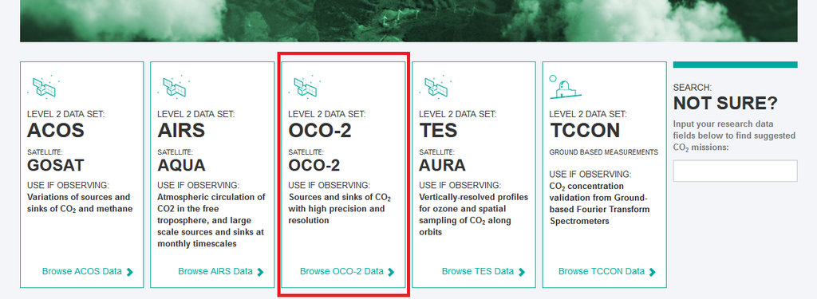

**3)** Role a página para baixo e acesse *CUSTOMIZE PRODUCT ON BUILD PAGE*.

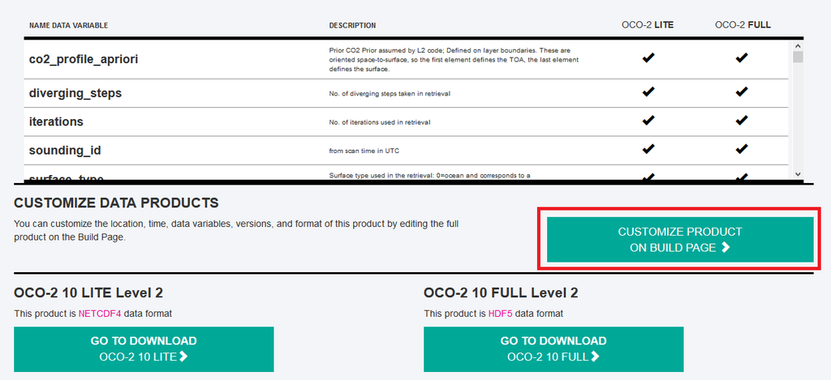

[figure not shown]

**5)** Em *DATA TYPE* selecione **OCO-2 Satellite**.

[figure not shown]

**6)** Em *PRODUCTS* selecione **OCO-2 Full**.

[figure not shown]

**7)** Em *DATA VERSION* selecione **10**.

[figure not shown]

**8)** Em *SPATIAL + TEMPORAL* selecione **Customize Your Spatial + Temporal Coverage**.

[figure not shown]

**OPTION 01** Utilize para selecionar a área para aquisição dos dados.

[figure not shown]

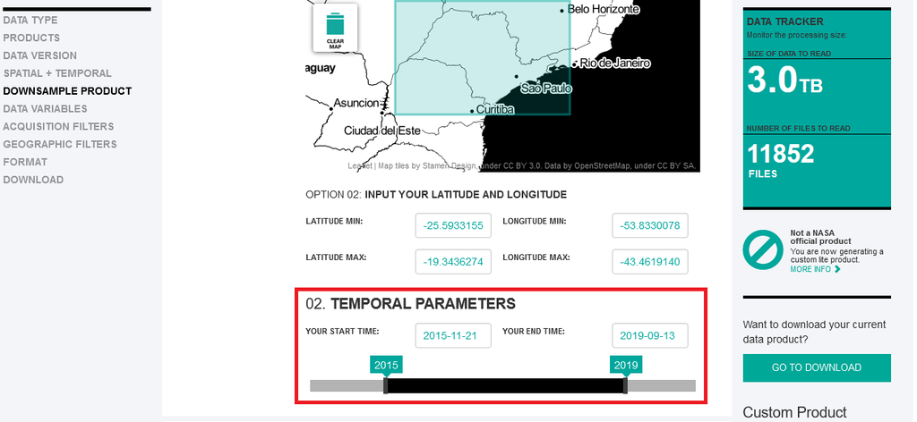

**9)** Em *DOWN SAMPLE PRODUCT* selecione **Yes, I want a Level 3 data product**. Altere os valores das células e o passo temporal desejado.

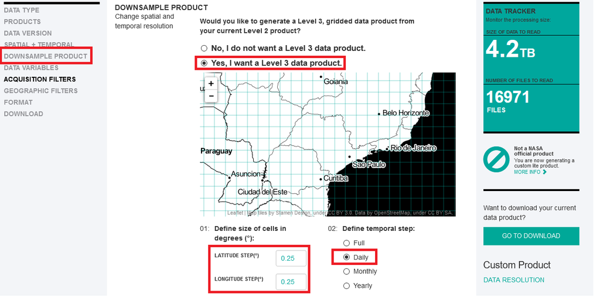

**10)** Em *DATA VARIABLES* selecione as variáveis desejadas.

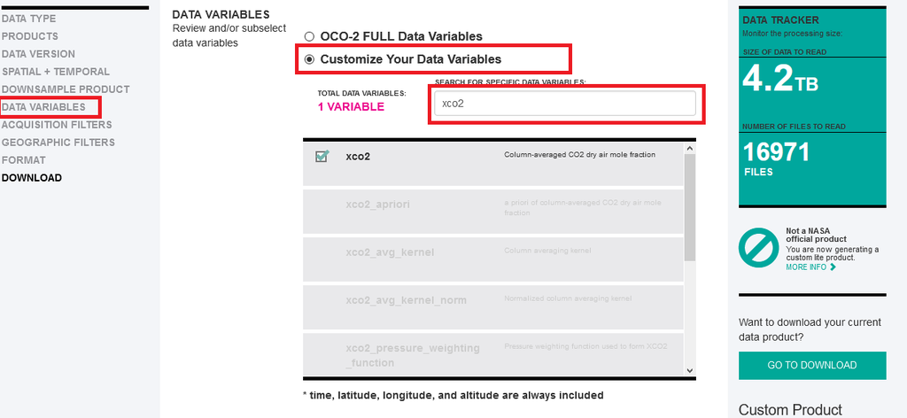

**11)** Abaixo são apresentadas as opções para os filtros e o tipo de arquivo, selecione **CSV FILE**.

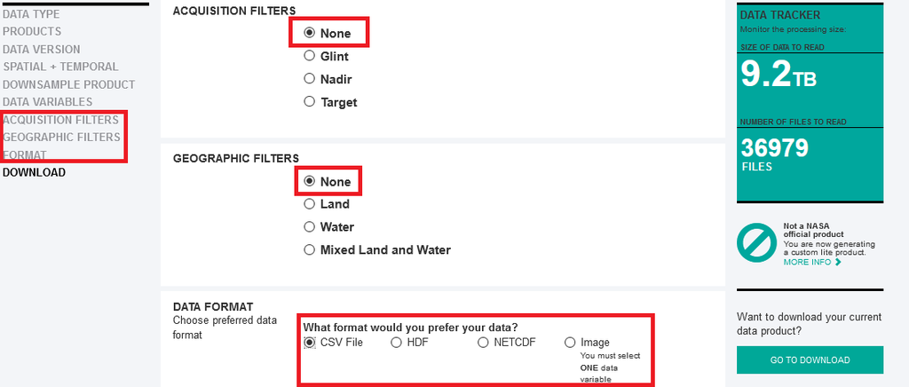

**12)** Forneça um endereço de e-mail para onde os links serão direcionados.

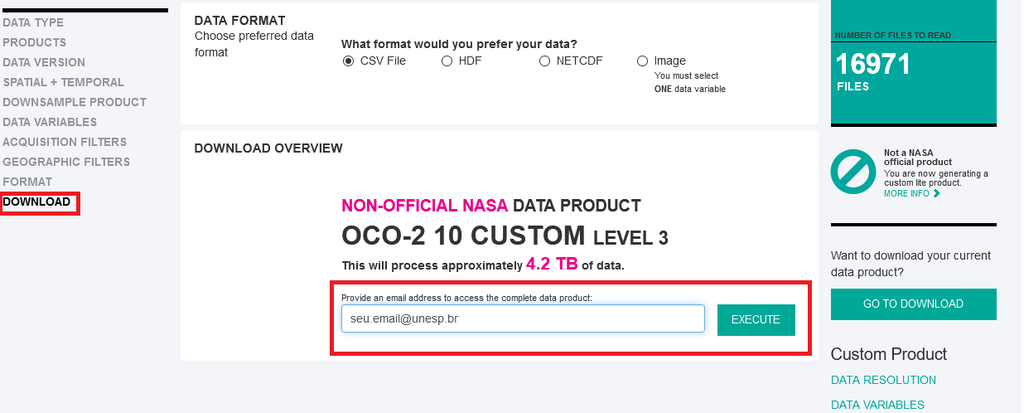

**13)** Acesse o seu e-mail, será enviado uma mensagem com o endereço dos arquivos onde você poderá acompanhar o progresso do processamento de seus dados. Ao final dessa etapa um novo e-mail é enviado informando que os dados estão disponíveis.

[figure not shown]

**14)** Acesse o link enviado em seu e-mail e você será direcionado a página.

[figure not shown]

**15)** Role a página para baixo e selecione a opção **WGET File List**.

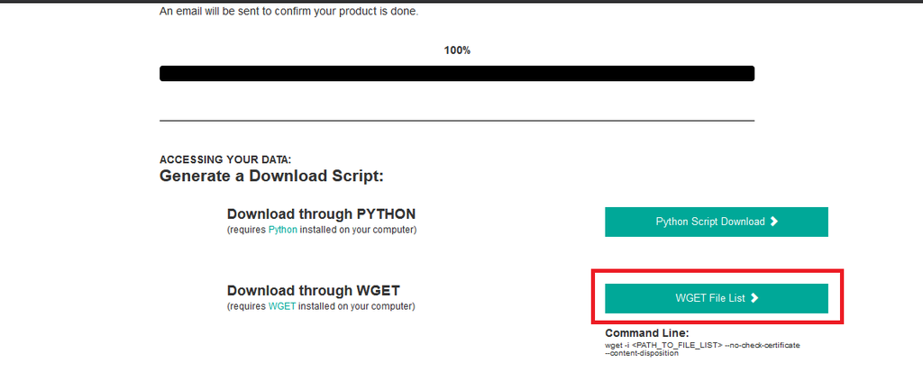

**16)** Salve o arquivo .txt na pasta `data-raw`.

[figure not shown]